# DEM manipulation and GIS workflow

The objective is to capture and transform **DEM** data into a **CSV** file that will later be use to set a bunch of properties for **Lecode** simulation.  
The data manipulation preserves the georeferencing information of the DEM, allowing later projection of the model in a GIS client (or google earth).  
Workflow description:

1. Download a DEM from the web (grid in lat/long coordinates),
2. Test the scene projection with GDAL,
3. Re-project the subset to UTM with GDAL in order to have a GeoTIF with pixels location in m,
4. Crop the new projection and export the DEM at a selected resolution in a xyz format (in m),
5. Perform the transformation to LECODE input format,
6. Analyse DEM for better definition of LECODE XmL input parameters.

## 1. Download a DEM from the web

Example of DEM providers:

- [NOAA](http://maps.ngdc.noaa.gov/viewers/wcs-client/) ETOPO1 (~1 km resolution)
- [CGIAR](http://srtm.csi.cgiar.org/SELECTION/inputCoord.asp) SRTM (90 m DEM)
- OGP’s [EPSG](http://www.epsg.org) Geodetic Parameter Datase
- *needs to be extended...*

After downloading the DEM, upload it to the Dropbox *SGFM-data* folder.  
*Note:*  
To be granted access to this folder you will need to send a request to SGFM support team.  
By uploading your DEM to the SGFM dropbox share folder, it will be directly accessible by the SGFM IP[y] Server for further processing.  
IMPORTANT:

- There is a limited number of space available on the SGFM dropbox share folder and you will have to remove your uploaded files after completion of the workflow.
- The iPython Notebook that you are editing however will be saved and you shoud be able to recreate your SGFM input just by uploading your files to the server.
- To facilitate this process we strongly recommend that you provide within your notebook some information on the uploaded DEM such as the name of the provider, the region extent, the projection references...

For the present notebook we used a SRTM ArcInfo ASCII from [CGIAR](http://srtm.csi.cgiar.org/SELECTION/inputCoord.asp):

Product: SRTM 90m DEM version 4

Data File Name: srtm_63_18.zip

Mask File Name: srtm_mk_63_18.zip

Latitude min: 30 S, max: 25 S

Longitude min: 130 E, max: 135 E

Center point: Latitude 27.50 S, Longitude 132.50 E

*Note:*  
Once on the server, your file will be accessible in the notebook via:

```
../SGFM-data/your_file_name
```

## 2. Test the scene projection with GDAL

First get information of the uploaded file and read general information about the upoaded file using *gdalinfo*. It will report all of the following (if known):

- The format driver used to access the file.
- Raster size (in pixels and lines).
- The coordinate system for the file (in OGC WKT).
- The geotransform associated with the file (rotational coefficients are currently not reported).
- Corner coordinates in georeferenced, and if possible lat/long based on the full geotransform (but not GCPs).
- Ground control points.
- File wide (including subdatasets) metadata.
- Band data types.
- Band color interpretations.
- Band block size.
- Band descriptions.
- Band min/max values (internally known and possibly computed).
- Band checksum (if computation asked).
- Band NODATA value.
- Band overview resolutions available.
- Band unit type (i.e.. "meters" or "feet" for elevation bands).
- Band pseudo-color tables.

*Note:*  
If the projection information is only required use the *GetProjectionRef()* function. This function which returns the projection reference as a [WKT string](http://en.wikipedia.org/wiki/Well-known_text). It shows the image geodetic system (here **WGS 84**) and other projection information such as unit, orgin, extent and ownership.

```python
"""
Open the file with GDAL.  What projection is it in?
"""
import os
import sys
from osgeo import gdal
from gdalconst import *
import matplotlib.pyplot as plt

# GDAL does not use python exceptions by default
gdal.UseExceptions()

# Transform the ArInfo ASCII grid to a Geotiff
!gdalwarp -t_srs WGS84 -ot Float32 ../SGFM-data/srtm_63_18/srtm_63_18.asc \
../SGFM-data/srtm_63_18/srtm_63_18.tif

# For a full overview of image information use gdalinfo command
!gdalinfo ../SGFM-data/srtm_63_18/srtm_63_18.tif

# If information on Projection Reference is only required used the following command
#gasc.GetProjectionRef()
```

```
Output dataset ../SGFM-data/srtm_63_18/srtm_63_18.tif exists,
but some commandline options were provided indicating a new dataset
should be created.  Please delete existing dataset and run again.
Driver: GTiff/GeoTIFF
Files: ../SGFM-data/srtm_63_18/srtm_63_18.tif
Size is 6001, 6001
Coordinate System is:
GEOGCS["WGS 84",
    DATUM["WGS_1984",
        SPHEROID["WGS 84",6378137,298.257223563,
            AUTHORITY["EPSG","7030"]],
        AUTHORITY["EPSG","6326"]],
    PRIMEM["Greenwich",0],
    UNIT["degree",0.0174532925199433],
    AUTHORITY["EPSG","4326"]]
Origin = (129.999583575470012,-24.999583357557686)
Pixel Size = (0.000833333333333,-0.000833333333333)
Metadata:
  AREA_OR_POINT=Area
Image Structure Metadata:
  INTERLEAVE=BAND
Corner Coordinates:
Upper Left  ( 129.9995836, -24.9995834) (129d59'58.50"E, 24d59'58.50"S)
Lower Left  ( 129.9995836, -30.0004167) (129d59'58.50"E, 30d 0' 1.50"S)
Upper Right ( 135.0004169, -24.9995834) (135d 0' 1.50"E, 24d59'58.50"S)
Lower Right ( 135.0004169, -30.0004167) (135d 0' 1.50"E, 30d 0' 1.50"S)
Center      ( 132.5000002, -27.5000000) (132d30' 0.00"E, 27d30' 0.00"S)
Band 1 Block=6001x1 Type=Float32, ColorInterp=Gray
```

To display the GeoTiff data within the notebook transform it to a numpy array and show it with Matplotlib.

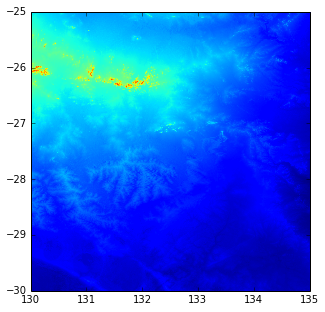

```python
# Open the file in iPython
gtif = gdal.Open('../SGFM-data/srtm_63_18/srtm_63_18.tif',GA_ReadOnly)

# Create the Numpy array
arr = gtif.ReadAsArray()

# Find geographic references and extent
trans = gtif.GetGeoTransform()
extent = (trans[0], trans[0] + gtif.RasterXSize*trans[1],
          trans[3] + gtif.RasterYSize*trans[5], trans[3])

# Display the array with Matplotlib
figure(figsize = (5,5))
plt.imshow(arr, extent=extent)
plt.show()
```

## 3. Re-project the subset to UTM

Now we re-project the image to **UTM** coordinate system in order to have the pixel location in metres.  
To convert to Universal Transverse Mercator (UTM), *gdalwarp* requires the UTM zone of your image. You can use [EPSG registry](http://www.epsg-registry.org/) webinterface to check if your UTM zone is correct. Using the registry you will:

- first use the `Show Map` button and select your area of interest.
- then in the `Type` box choose `Coordinate Reference System / Projected CRS` and for the Name put the current GIS (here **WGS 84**), and click `Search`
- a table will appear, look to find within the `Area Description` column which one contains your simulation domain and use the corresponding `Code` in your `gdalwarp` function.

Then you can use *gdalinfo* to check that the re-projection works fine.

```python
# Convert from WGS84 to UTM 52S
!gdalwarp -t_srs '+proj=utm +zone=52 +south +datum=WGS84' \
../SGFM-data/srtm_63_18/srtm_63_18.tif ../SGFM-data/srtm_63_18/utm_63_18.tif
gutm = gdal.Open('../SGFM-data/srtm_63_18/utm_63_18.tif',GA_ReadOnly)

# Check projected map information using gdalinfo command
!gdalinfo ../SGFM-data/srtm_63_18/utm_63_18.tif
```

[output not shown]

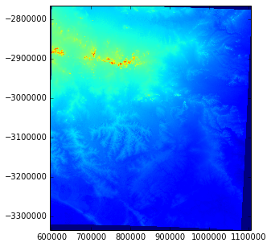

```python
# Open the UTM map in IPython
gutm = gdal.Open('../SGFM-data/srtm_63_18/utm_63_18.tif',GA_ReadOnly)

# Create the Numpy array
arr_utm = gutm.ReadAsArray()

# Find geographic references and extent
trans_utm = gutm.GetGeoTransform()
uextent = (trans_utm[0], trans_utm[0] + gutm.RasterXSize*trans_utm[1],
          trans_utm[3] + gutm.RasterYSize*trans_utm[5], trans_utm[3])

# Display the array with Matplotlib
figure(figsize = (5,5))
plt.imshow(arr_utm, extent=uextent)
plt.show()
```